# PCA analysis on seeds distribution in Mendoza, Argentina

## 1 *Background*

Seeds, an important food resource for consumers in deserts, often have highly heterogeneous abundances in the soil seed bank at small scales (centimeters to meters), in relation to the structure of the vegetation. For example, they tend to be much more abundant under the canopy of woody plants.

To evaluate whether granivorous birds (seed consumers) in the Central Mountain Desert (Mendoza, Argentina) select feeding sites, the characteristics of the sites where birds were observed feeding on seeds were compared with those of 60 randomly located sites in the same area to represent the heterogeneity available in the environment. This analysis was done in areas with a 1-meter radius, and a series of structural variables were estimated:

- Horizontal cover of grasses (GRAMS), subshrubs (SUBARBTS), shrubs (ARBTS), and trees (ARBS)
- Vegetation density (the sum of the number of strata occupied at all points of each microsite; DENSIDAD)
- Variation in maximum height between points of each microsite (CVALT)
- Horizontal cover of bare soil (SUEDES) and dense mulch (MANTI)

```r
#Loading the data
pathBase = file.path(dirname(rstudioapi::getSourceEditorContext()$path))
seeds  <- read_delim(paste0(pathBase, "/seeds-PCA.txt"), delim = "\t", escape_double = FALSE, trim_ws = TRUE)
attach(seeds)
seeds$Grupo = as.factor(seeds$Grupo)
```

## 2 *Descriptive analytics*

As this is a multivariate type of analysis, we are resticted in the number of axis we can visualize the data altogether. If we plot 3 of the variables sampled, we can’t see crystal clear if there are or not any pattern that guide this phenomenon.

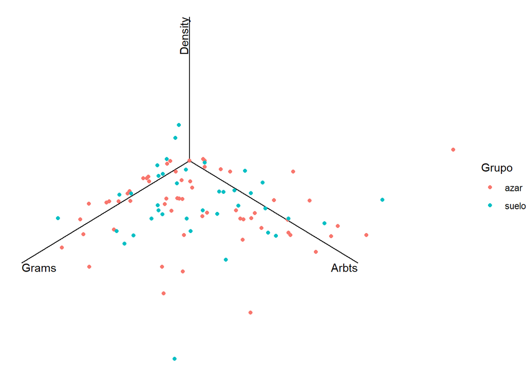

```r
ggplot(seeds, aes(x=Grams, y=Arbts, z=Densidad, color=Grupo)) +
  theme_void() +
  axes_3D() +
  stat_3D()+
  labs_3D(labs=c("Grams", "Arbts", "Density"),
          hjust=c(0,1,1), vjust=c(1, 1, -0.2), angle=c(0, 0, 90))
```

We can take this a step further plotting the correlation matrix for all the variables in the dataset.

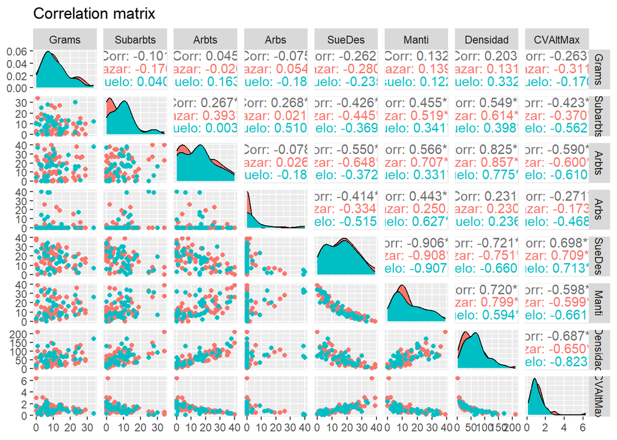

```r
ggpairs(data = seeds, columns = 2:ncol(seeds),
        alpha=0.4, ggplot2::aes(colour = Grupo),
        title = 'Correlation matrix',
        upper = list(continuous = "cor"),
        lower = list(continuous = "points"))
```

## 3 *PCA*

```r
kable(round(cor <- cor(seeds[2:ncol(seeds)]),2),
      caption = "Covariance matrix")  #R matrix
```

|  | Grams | Subarbts | Arbts | Arbs | SueDes | Manti | Densidad | CVAltMax |
| --- | --- | --- | --- | --- | --- | --- | --- | --- |
| Grams | 1.00 | -0.10 | 0.04 | -0.07 | -0.26 | 0.13 | 0.20 | -0.26 |
| Subarbts | -0.10 | 1.00 | 0.27 | 0.27 | -0.43 | 0.45 | 0.55 | -0.42 |
| Arbts | 0.04 | 0.27 | 1.00 | -0.08 | -0.55 | 0.57 | 0.82 | -0.59 |
| Arbs | -0.07 | 0.27 | -0.08 | 1.00 | -0.41 | 0.44 | 0.23 | -0.27 |
| SueDes | -0.26 | -0.43 | -0.55 | -0.41 | 1.00 | -0.91 | -0.72 | 0.70 |
| Manti | 0.13 | 0.45 | 0.57 | 0.44 | -0.91 | 1.00 | 0.72 | -0.60 |
| Densidad | 0.20 | 0.55 | 0.82 | 0.23 | -0.72 | 0.72 | 1.00 | -0.69 |
| CVAltMax | -0.26 | -0.42 | -0.59 | -0.27 | 0.70 | -0.60 | -0.69 | 1.00 |

### 3.2 Adjusting the model

```r
data_matrix <- data.matrix(seeds[2:8], rownames.force=NA) # Convert to data.matrix to use vegan::rda()
PCA <- rda(data_matrix, scale=TRUE)
pca_summ <- summary(PCA)$cont$importance
kable(pca_summ, caption = "PCA Summary: Importance of Components")
```

PCA Summary: Importance of Components

|  | PC1 | PC2 | PC3 | PC4 | PC5 | PC6 | PC7 |
| --- | --- | --- | --- | --- | --- | --- | --- |
| Eigenvalue | 3.6083648 | 1.2288215 | 1.0318180 | 0.6398193 | 0.3431196 | 0.0841987 | 0.0638581 |
| Proportion Explained | 0.5154807 | 0.1755459 | 0.1474026 | 0.0914028 | 0.0490171 | 0.0120284 | 0.0091226 |
| Cumulative Proportion | 0.5154807 | 0.6910266 | 0.8384292 | 0.9298319 | 0.9788490 | 0.9908774 | 1.0000000 |

### 3.3 How many components?

Selecting how many components based on variability they represent, *i.e.* importance of components

#### 3.3.1 Criteria 1: Eigenvalues

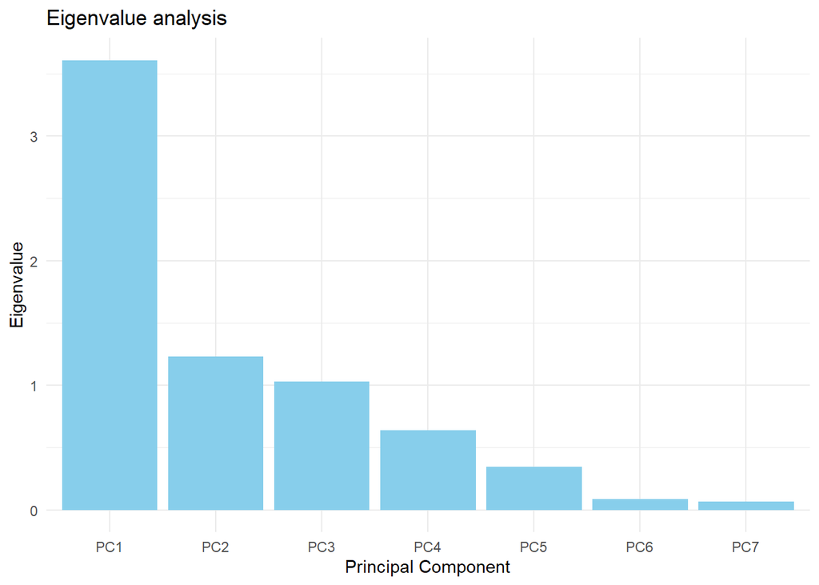

```r
# Eigenvalues
PC_values <- PCA$CA$eig
eigenvalues <- data.frame(PC = paste0("PC", 1:7), PC_value = PC_values)

ggplot(eigenvalues, aes(x = PC, y = PC_value)) +
  geom_bar(stat = "identity", fill = "skyblue") +
  labs(title = "Eigenvalue analysis", x = "Principal Component", y = "Eigenvalue") +
  theme_minimal()
```

[figure not shown]

```r
proportion <- summary(PCA)$cont$importance[2, ]
cummulative_proportion <- data.frame(PC = paste0("PC", 1:7), Cummulative_prop = proportion)

ggplot(cummulative_proportion, aes(x = PC, y = Cummulative_prop)) +
  geom_bar(stat = "identity", fill = "skyblue", alpha=0.75) +
  geom_line(group = 1, color = "black", size = 1) +
  geom_point(color = "black", size = 3) +
  geom_text(aes(label = round(Cummulative_prop, 2)), vjust = -0.5, color = "black", size = 4) +
  labs(title = "Cummulative proportion analysis", x = "Principal Component", y = "Proportion") +
  theme_minimal()
```

## 4 *Plotting the results of PCA: the biplot*

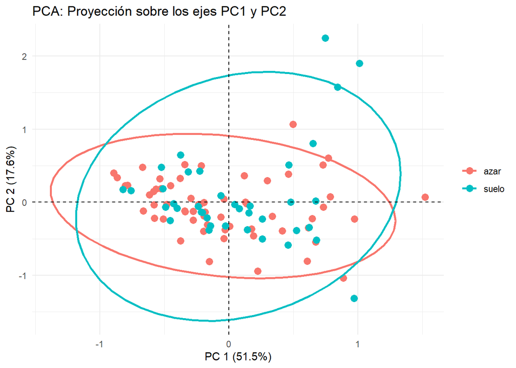

```r
scores_PCA <- scores(PCA, choices = c(1, 2))
seeds$Grupo <- as.factor(seeds$Grupo)
PCA_df <- data.frame(scores_PCA, Grupo = seeds$Grupo)

PC1label = paste0("PC 1 (", round(cummulative_proportion[1,]$Cummulative_prop, 3)*100, "%)")
PC2label = paste0("PC 2 (", round(cummulative_proportion[2,]$Cummulative_prop, 3)*100, "%)")

ggplot(PCA_df, aes(x = sites.PC1, y = sites.PC2, color = Grupo)) +
  geom_point(size = 3) +
  stat_ellipse(type = "norm", size = 1) +
  labs(title = "PCA: Proyección sobre los ejes PC1 y PC2", x = `PC1label`, y = `PC2label`) +
  theme_minimal() +
  theme(legend.title = element_blank()) +
  geom_vline(xintercept=0, linetype='dashed') +
  geom_hline(yintercept=0, linetype='dashed')
```

## 5 *Interpretation of results*

```r
loadings <- scores(PCA, display = "species")
kable(loadings)
```

|  | PC1 | PC2 |
| --- | --- | --- |
| Grams | 0.3571523 | -1.1324512 |
| Subarbts | 1.1773743 | 0.6577768 |
| Arbts | 1.4118748 | -0.8296209 |
| Arbs | 0.8026608 | 1.4115042 |
| SueDes | -1.7520788 | -0.0116680 |
| Manti | 1.7613230 | 0.1818070 |
| Densidad | 1.7631626 | -0.3813002 |